# FeatureScaling_day_16

## 1. What is feature scaling and why is it required?

## Feature Scaling

**Definition:**  
Feature scaling is the process of transforming the range of numerical features so that all features have a similar scale. Common techniques include **Min-Max Scaling** (0–1) and **Standardization** (mean = 0, std = 1).

**Why it is required:**  
Many machine learning algorithms are sensitive to the magnitude of features. Feature scaling is important because:

- **Distance-based algorithms** (e.g., KNN, K-Means, SVM) can be dominated by features with larger ranges.
- **Gradient-based optimization** (e.g., Linear Regression, Neural Networks) converges faster and more reliably.
- **Regularization** (e.g., Ridge, Lasso) treats all features fairly, preventing large-scale features from dominating.

**Key takeaway:**  
Scaling ensures all features contribute equally, improves model performance, and helps faster convergence during training.

## 2. What is the difference between normalization and standardization?

| Feature | Normalization | Standardization |
| --- | --- | --- |
| **Definition** | Rescales features to a fixed range (e.g., 0–1) | Centers features to mean 0 and scales to std 1 |
| **Formula** | x' = (x - min) / (max - min) | x' = (x - mean) / std |
| **Range** | Fixed (usually 0–1) | Depends on data (mean = 0, std = 1) |
| **Use case** | Distance-based algorithms (KNN, K-Means, neural networks with bounded inputs) | Algorithms assuming normal distribution or different units (Regression, SVM, Neural Networks) |
| **Sensitivity to outliers** | High | Lower |
| **Key idea** | Adjusts the **scale/range** | Adjusts the **distribution** |

## 3. what is Min-Max Scaling ?

Min-Max Scaling is a feature scaling technique that rescales numerical features to a fixed range, usually 0 to 1. Each value is transformed using the formula `x' = (x - min) / (max - min)`, where `min` and `max` are the minimum and maximum values of the feature. This scaling preserves the original distribution of the data while ensuring that all features are on the same scale, which is especially important for distance-based algorithms like K-Nearest Neighbors, K-Means, and neural networks. Unlike standardization, which centers data to mean 0 and standard deviation 1, Min-Max Scaling compresses or stretches data to a fixed range.

## 4.What is z-score standardization?

Z-score standardization, also called standardization, is a feature scaling technique that transforms data to have a **mean of 0 and a standard deviation of 1**. Each value is calculated using the formula `z = (x - mean) / std`, where `mean` is the average of the feature and `std` is its standard deviation. This scaling ensures that features with different units or ranges contribute equally to machine learning models, improves convergence for gradient-based algorithms, and allows fair comparison across features. Unlike Min-Max scaling, Z-score standardization adjusts the **distribution** of the data rather than mapping it to a fixed range.

## 5. what is the range of Values after Min-Max Scaling?

After Min-Max Scaling, the values of a feature are **rescaled to a fixed range**, typically **0 to 1**. The minimum value of the feature becomes 0, the maximum becomes 1, and all other values are proportionally mapped between 0 and 1. Optionally, a different range `[a, b]` can be chosen, in which case values are scaled to that range instead of 0–1.

## 6. What does a z-score represent statistically?

A z-score expresses how far and in what direction a data point deviates from the mean of its distribution, measured in units of standard deviation. A positive z-score means the value lies above the mean, while a negative z-score means it lies below. This statistical measure provides a way to understand the relative position of a value within its dataset, making it possible to compare values across different features or datasets even if they are measured on different scales. By standardizing values in this way, z-scores help identify outliers, assess probabilities, and enable meaningful comparisons in statistical analysis.

## 7. Why is scaling important for distance-based algorithms?

Scaling is crucial for distance-based algorithms like **K-Nearest Neighbors (KNN), K-Means, and clustering methods** because these algorithms compute distances between data points to make predictions or form clusters. Features with larger numerical ranges can dominate the distance calculation, overshadowing features with smaller ranges. By scaling features to the same range (e.g., using Min-Max Scaling or Z-score Standardization), all features contribute equally, ensuring that the algorithm accurately reflects the true similarity or dissimilarity between data points.

## 8. Which scaling technique is sensitive to outliers and why?

**Min-Max Scaling** is sensitive to outliers because it rescales data based on the **minimum and maximum values** of the feature. If a feature contains extreme values, the min or max is affected, which **compresses the majority of the data into a smaller range** and can distort the representation of normal data points. In contrast, Z-score standardization is less sensitive to outliers because it uses the **mean and standard deviation**, which are less influenced by a single extreme value.

## 9.Write a normalization(data) function using min-max scaling from scratch.

```python
x =[4 ,3 ,8 ,7,2,10,5,15]
y=[1500,1800,2500,2000,1800,1400,1900,2600]


def normalization(data):
    if not data:
        return []
    min_val =min(data)
    max_val =max(data)

    if min_val == max_val:
        return [0 for _ in data]

    normal= []
    for x in data:
        y = (x-min_val) / (max_val - min_val)
        normal.append(y)
    return normal

normal_x =normalization(x)
normal_y = normalization(y)
print("The normalization of x is ",normal_x)
print("The normalization of y is ",normal_y)
```

```
The normalization of x is  [0.15384615384615385, 0.07692307692307693, 0.46153846153846156, 0.38461538461538464, 0.0, 0.6153846153846154, 0.23076923076923078, 1.0]
The normalization of y is  [0.08333333333333333, 0.3333333333333333, 0.9166666666666666, 0.5, 0.3333333333333333, 0.0, 0.4166666666666667, 1.0]
```

## 10. Write a standardization(data) function using mean and std from scratch.

```python
x =[4 ,3 ,8 ,7,2,10,5,15]
y=[1500,1800,2500,2000,1800,1400,1900,2600]

def standardization(data):
    if not data:
        return []

    mean = sum(data) / len(data)
    std = (sum((x-mean)**2 for x in data) / len(data)) **0.5

    if std ==0:
        return [0 for _ in data]
    standard = []
    for x in data:
        z = (x-mean) / std
        standard.append(z)
    return standard

standard_x = standardization(x)
standard_y = standardization(y)
print("The standardization of x is ",standard_x)
print("the standardization of y is ",standard_y)
```

```
The standardization of x is  [-0.6888467201936644, -0.9393364366277243, 0.31311214554257477, 0.06262242910851495, -1.1898261530617842, 0.8140915784106943, -0.4383570037596047, 2.066540160580993]
the standardization of y is  [-1.0942844490912642, -0.3439179697143973, 1.4069371488316254, 0.1563263498701806, -0.3439179697143973, -1.3444066088835531, -0.09379580992210836, 1.6570593086239143]
```

## 11. Modify scaling functions to ignore missing values.

```python
x =[4 ,3 ,8 ,7,2,10,5,15,'',None]
y=[1500,1800,2500,2000,1800,'',1400,1900,2600]

def normalization(data):
    if not data:
        return []
    data =[x for x in data if x not in ('',None)]
    min_val =min(data)
    max_val =max(data)

    if min_val == max_val:
        return [0 for _ in data]

    normal= []
    for x in data:
        y = (x-min_val) / (max_val - min_val)
        normal.append(y)
    return normal

def standardization(data1):

    data =[x for x in data1 if x not in ('',None)]
    mean = sum(data) / len(data)
    std = (sum((x-mean)**2 for x in data) / len(data)) **0.5

    if std ==0:
        return [0 for _ in data]

    standard = []
    for value in data1:
        if value not in ('',None):
            z = (value-mean) / std
            standard.append(z)
        else:
            standard.append(None)
    return standard

# igonred for standardization
standard_x = standardization(x)
standard_y = standardization(y)
print("The standardization of x is ",standard_x)
print("the standardization of y is ",standard_y)

# dropped for normalization
normal_x =normalization(x)
normal_y = normalization(y)
print("The normalization of x is ",normal_x)
print("The normalization of y is ",normal_y)
```

```
The standardization of x is  [-0.6888467201936644, -0.9393364366277243, 0.31311214554257477, 0.06262242910851495, -1.1898261530617842, 0.8140915784106943, -0.4383570037596047, 2.066540160580993, None, None]
the standardization of y is  [-1.0942844490912642, -0.3439179697143973, 1.4069371488316254, 0.1563263498701806, -0.3439179697143973, None, -1.3444066088835531, -0.09379580992210836, 1.6570593086239143]
The normalization of x is  [0.15384615384615385, 0.07692307692307693, 0.46153846153846156, 0.38461538461538464, 0.0, 0.6153846153846154, 0.23076923076923078, 1.0]
The normalization of y is  [0.08333333333333333, 0.3333333333333333, 0.9166666666666666, 0.5, 0.3333333333333333, 0.0, 0.4166666666666667, 1.0]
```

## 12. Apply both scaling methods to the same column and compare outputs.

```
Original column:     [4, 3, 8, 7, 2, 10, 5, 15, '', None]
Normalized column:   [0.15384615384615385, 0.07692307692307693, 0.46153846153846156, 0.38461538461538464, 0.0, 0.6153846153846154, 0.23076923076923078, 1.0, None, None]
Standardized column: [-0.6443571047419068, -0.8786687791935092, 0.2928895930645031, 0.05857791861290061, -1.1129804536451116, 0.761512941967708, -0.41004543029030427, 1.9330713142257203, None, None]
```

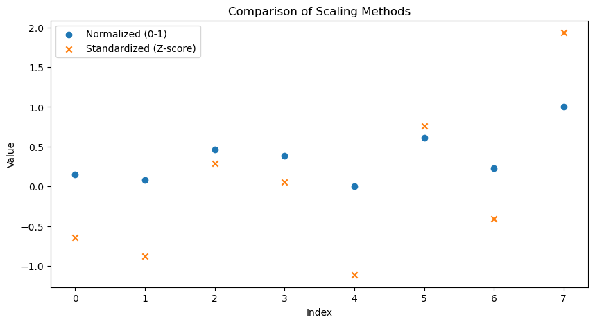

```python
import matplotlib.pyplot as plt

# Sample column with some missing values
column = [4, 3, 8, 7, 2, 10, 5, 15, '', None]

# Min-Max Normalization

def normalization(data):
    clean_data = [v for v in data if v not in ('', None)]
    if not clean_data:
        return [None for _ in data]

    min_val = min(clean_data)
    max_val = max(clean_data)

    if min_val == max_val:
        return [0 if v not in ('', None) else None for v in data]

    normalized = []
    for v in data:
        if v in ('', None):
            normalized.append(None)
        else:
            normalized.append((v - min_val) / (max_val - min_val))
    return normalized

# Z-score Standardization
def standardization(data):
    clean_data = [v for v in data if v not in ('', None)]
    if not clean_data:
        return [None for _ in data]

    n = len(clean_data)
    mean_val = sum(clean_data) / n
    std_val = (sum((v - mean_val) ** 2 for v in clean_data) / (n - 1)) ** 0.5

    if std_val == 0:
        return [0 if v not in ('', None) else None for v in data]

    standardized = []
    for v in data:
        if v in ('', None):
            standardized.append(None)
        else:
            standardized.append((v - mean_val) / std_val)
    return standardized


# Apply scaling

normalized_col = normalization(column)
standardized_col = standardization(column)

print("Original column:    ", column)
print("Normalized column:  ", normalized_col)
print("Standardized column:", standardized_col)

plt.figure(figsize=(10,5))
plt.scatter(range(len(normalized_col)),normalized_col, marker='o', label='Normalized (0-1)')
plt.scatter(range(len(standardized_col)),standardized_col, marker='x', label='Standardized (Z-score)')
plt.title("Comparison of Scaling Methods")
plt.xlabel("Index")
plt.ylabel("Value")
plt.legend()
plt.show()
```

## 13. Write code to scale multiple columns using reusable functions.

```python
# code if we passed data as a list
def scale_column(data, method="normalize"):
    clean = [v for v in data if v not in ('', None)]
    if not clean:
        return [None for _ in data]

    result = []

    if method == "normalize":
        min_val = min(clean)
        max_val = max(clean)

        if min_val == max_val:
            return [0 if v not in ('', None) else None for v in data]

        for v in data:
            if v in ('', None):
                result.append(None)
            else:
                result.append((v - min_val) / (max_val - min_val))
        return result

    if method == "standardize":
        n = len(clean)
        mean = sum(clean) / n
        std = (sum((v - mean) ** 2 for v in clean) / (n - 1)) ** 0.5

        if std == 0:
            return [0 if v not in ('', None) else None for v in data]

        for v in data:
            if v in ('', None):
                result.append(None)
            else:
                result.append((v - mean) / std)
        return result


data = [4, 3, 8, 7, 2, 10, 5, 15, '', None]

print("Normalized:")
print(scale_column(data, method="normalize"))

print("\nStandardized:")
print(scale_column(data, method="standardize"))
```

```
Normalized:
[0.15384615384615385, 0.07692307692307693, 0.46153846153846156, 0.38461538461538464, 0.0, 0.6153846153846154, 0.23076923076923078, 1.0, None, None]

Standardized:
[-0.6443571047419068, -0.8786687791935092, 0.2928895930645031, 0.05857791861290061, -1.1129804536451116, 0.761512941967708, -0.41004543029030427, 1.9330713142257203, None, None]
```

```python
# code if we passed data as dictionary

def scale_columns(data, method="normalize"):
    # remove missing values for calculation
    clean = [v for v in data if v not in ('', None)]

    if not clean:
        return [None for _ in data]

    result = []

    #  Normalization
    if method == "normalize":
        min_val = min(clean)
        max_val = max(clean)

        # avoid division by zero
        if min_val == max_val:
            return [0 if v not in ('', None) else None for v in data]

        for v in data:
            if v in ('', None):
                result.append(None)
            else:
                result.append((v - min_val) / (max_val - min_val))

        return result

    #  Standardization
    if method == "standardize":
        n = len(clean)
        mean = sum(clean) / n
        std = (sum((v - mean) ** 2 for v in clean) / (n - 1)) ** 0.5

        # avoid division by zero
        if std == 0:
            return [0 if v not in ('', None) else None for v in data]

        for v in data:
            if v in ('', None):
                result.append(None)
            else:
                result.append((v - mean) / std)

        return result


# Scale ALL columns in dictionary
def scale_dictionary(data_dict, method="normalize"):
    scaled_data = {}

    for column_name, column_values in data_dict.items():
        scaled_data[column_name] = scale_columns(column_values, method)

    return scaled_data


# Example Dataset (Dictionary)
data = {
    "x": [4, 3, 8, 7, 2, 10, 5, 15, '', None],
    "y": [1500, 1800, 2500, 2000, 1800, '', 1400, 1900, 2600]
}


# Apply Scaling
normalized_data = scale_dictionary(data, "normalize")
standardized_data = scale_dictionary(data, method="standardize")


# Output
print("Normalized Data:")
for col, values in normalized_data.items():
    print(col, ":", values)

print("\nStandardized Data:")
for col, values in standardized_data.items():
    print(col, ":", values)
```

```
Normalized Data:
x : [0.15384615384615385, 0.07692307692307693, 0.46153846153846156, 0.38461538461538464, 0.0, 0.6153846153846154, 0.23076923076923078, 1.0, None, None]
y : [0.08333333333333333, 0.3333333333333333, 0.9166666666666666, 0.5, 0.3333333333333333, None, 0.0, 0.4166666666666667, 1.0]

Standardized Data:
x : [-0.6443571047419068, -0.8786687791935092, 0.2928895930645031, 0.05857791861290061, -1.1129804536451116, 0.761512941967708, -0.41004543029030427, 1.9330713142257203, None, None]
y : [-1.0236093730435454, -0.3217058029565429, 1.31606919391313, 0.14622991043479222, -0.3217058029565429, None, -1.257577229739213, -0.08773794626087533, 1.5500370506087975]
```

## 14. Add validation to avoid division-by-zero errors.

```python
# code if we passed data as a list
def scale_column(data, method="normalize"):
    clean = [v for v in data if v not in ('', None)]
    if not clean:
        return [None for _ in data]

    result = []

    if method == "normalize":
        min_val = min(clean)
        max_val = max(clean)

        if min_val == max_val:
            return [0 if v not in ('', None) else None for v in data]

        for v in data:
            if v in ('', None):
                result.append(None)
            else:
                result.append((v - min_val) / (max_val - min_val))
        return result

    if method == "standardize":
        n = len(clean)
        if n <2:
            return [0 if c not in ('',None) else None for c in data]
        mean = sum(clean) / n
        std = (sum((v - mean) ** 2 for v in clean) / (n - 1)) ** 0.5

        if std == 0:
            return [0 if v not in ('', None) else None for v in data]

        for v in data:
            if v in ('', None):
                result.append(None)
            else:
                result.append((v - mean) / std)
        return result


data = [4, 3, 8, 7, 2, 10, 5, 15, '', None]

print("Normalized:")
print(scale_column(data, method="normalize"))

print("\nStandardized:")
print(scale_column(data, method="standardize"))
```

```
Normalized:
[0.15384615384615385, 0.07692307692307693, 0.46153846153846156, 0.38461538461538464, 0.0, 0.6153846153846154, 0.23076923076923078, 1.0, None, None]

Standardized:
[-0.6443571047419068, -0.8786687791935092, 0.2928895930645031, 0.05857791861290061, -1.1129804536451116, 0.761512941967708, -0.41004543029030427, 1.9330713142257203, None, None]
```

## 15. Write a function that automatically detects which scaling method to use

```python
# Scale a single column
def scale_column(data, method="normalize"):
    clean = [v for v in data if v not in ('', None)]
    if not clean:
        return [None for _ in data]

    result = []

    if method == "normalize":
        min_val = min(clean)
        max_val = max(clean)

        if min_val == max_val:
            return [0 if v not in ('', None) else None for v in data]

        for v in data:
            if v in ('', None):
                result.append(None)
            else:
                result.append((v - min_val) / (max_val - min_val))
        return result

    if method == "standardize":
        n = len(clean)
        mean = sum(clean) / n
        std = (sum((v - mean) ** 2 for v in clean) / n) ** 0.5

        if std == 0:
            return [0 if v not in ('', None) else None for v in data]

        for v in data:
            if v in ('', None):
                result.append(None)
            else:
                result.append((v - mean) / std)
        return result


# Auto-scaling for a single column (with method info)
def scale_column_auto(data, col_name="Column"):
    clean = [v for v in data if v not in ('', None)]
    if not clean:
        print(f"{col_name}: No valid data to scale")
        return [None for _ in data]

    min_val = min(clean)
    max_val = max(clean)

    # Heuristic: use standardization if range is large
    if max_val / (min_val + 1e-9) > 10:  # avoid division by zero
        method = "standardize"
    else:
        method = "normalize"

    print(f"{col_name}: Using {method} scaling")  # print method
    return scale_column(data, method=method)


# Auto-scaling for multiple columns (dictionary)
def scale_dict_auto(data_dict):
    scaled_data = {}
    for col, values in data_dict.items():
        scaled_data[col] = scale_column_auto(values, col_name=col)
    return scaled_data


# Example Dataset
data = {
    "rooms": [4, 3, 8, 7, 2, 10, 5, 125, '', None],
    "price": [1500, 1800, 2500, 2000, 1800, '', 1400, 1900, 2600]
}

# Apply Auto Scaling
scaled_data = scale_dict_auto(data)

# Output Scaled Data
print("\nAuto-scaled Data:")
for col, values in scaled_data.items():
    print(col, ":", values)
```

```
rooms: Using standardize scaling
price: Using normalize scaling

Auto-scaled Data:
rooms : [-0.41692064618998337, -0.4421885641408914, -0.315848974386351, -0.3411168923372591, -0.4674564820917995, -0.26531313848453486, -0.39165272823907527, 2.6404974258698948, None, None]
price : [0.08333333333333333, 0.3333333333333333, 0.9166666666666666, 0.5, 0.3333333333333333, None, 0.0, 0.4166666666666667, 1.0]
```

## 16. Scale data before and after outlier removal and compare results.

```python
# Simple scaling function (min-max)
def normalize(data):
    clean = [v for v in data if v not in ('', None)]
    if not clean:
        return [None for _ in data]
    min_val = min(clean)
    max_val = max(clean)
    if min_val == max_val:
        return [0 if v not in ('', None) else None for v in data]
    result = []
    for v in data:
        if v in ('', None):
            result.append(None)
        else:
            result.append((v - min_val) / (max_val - min_val))
    return result

# Simple IQR outlier removal
def remove_outliers(data):
    clean = [v for v in data if v not in ('', None)]
    if not clean:
        return data
    sorted_data = sorted(clean)
    n = len(sorted_data)

    q1 = sorted_data[n // 4]
    q3 = sorted_data[(3 * n) // 4]
    iqr = q3 - q1
    lower = q1 - 1.5 * iqr
    upper = q3 + 1.5 * iqr

    # Keep None/'' in same positions
    result = []
    for v in data:
        if v in ('', None):
            result.append(None)
        elif lower <= v <= upper:
            result.append(v)
        else:
            result.append(None)  # remove outlier
    return result

# Example Data
data = [10, 12, 14, 15, 13, 100, 12, 11, 14]  # 100 is outlier

# Scale BEFORE outlier removal
scaled_before = normalize(data)

# Remove outliers
cleaned_data = remove_outliers(data)

# Scale AFTER outlier removal
scaled_after = normalize(cleaned_data)

# Output Results
print("Original Data:       ", data)
print("Scaled BEFORE remove:", scaled_before)
print("Cleaned Data:        ", cleaned_data)
print("Scaled AFTER remove: ", scaled_after)
```

```
Original Data:        [10, 12, 14, 15, 13, 100, 12, 11, 14]
Scaled BEFORE remove: [0.0, 0.022222222222222223, 0.044444444444444446, 0.05555555555555555, 0.03333333333333333, 1.0, 0.022222222222222223, 0.011111111111111112, 0.044444444444444446]
Cleaned Data:         [10, 12, 14, 15, 13, None, 12, 11, 14]
Scaled AFTER remove:  [0.0, 0.4, 0.8, 1.0, 0.6, None, 0.4, 0.2, 0.8]
```

## 17. Store scaled outputs in a new dataset without modifying original data.

```python
# Scaling function (min-max)
def normalize(data):
    clean = [v for v in data if v not in ('', None)]
    if not clean:
        return [None for _ in data]
    min_val = min(clean)
    max_val = max(clean)
    if min_val == max_val:
        return [0 if v not in ('', None) else None for v in data]
    return [(v - min_val) / (max_val - min_val) if v not in ('', None) else None for v in data]

# Outlier removal function (IQR)
def remove_outliers(data):
    clean = [v for v in data if v not in ('', None)]
    if not clean:
        return data[:]
    sorted_data = sorted(clean)
    n = len(sorted_data)
    q1 = sorted_data[n // 4]
    q3 = sorted_data[(3 * n) // 4]
    iqr = q3 - q1
    lower = q1 - 1.5 * iqr
    upper = q3 + 1.5 * iqr

    # Keep original positions, replace outliers with None
    return [v if (v not in ('', None) and lower <= v <= upper) else None for v in data]

# Example Original Dataset
original_data = {
    "scores": [10, 12, 14, 15, 13, 100, 12, 11, 14],  # 100 is outlier
    "hours": [2, 3, 5, 4, 3, 20, 4, 3, 5]  # 20 is outlier
}

# Store scaled outputs separately
scaled_dataset = {}  # new dataset

for col, values in original_data.items():
    # Remove outliers first
    cleaned = remove_outliers(values)
    # Scale the cleaned data
    scaled_dataset[col] = normalize(cleaned)

# Output
print("Original Dataset:")
for col, values in original_data.items():
    print(col, ":", values)

print("\nScaled Dataset (after outlier removal):")
for col, values in scaled_dataset.items():
    print(col, ":", values)
```

```
Original Dataset:
scores : [10, 12, 14, 15, 13, 100, 12, 11, 14]
hours : [2, 3, 5, 4, 3, 20, 4, 3, 5]

Scaled Dataset (after outlier removal):
scores : [0.0, 0.4, 0.8, 1.0, 0.6, None, 0.4, 0.2, 0.8]
hours : [0.0, 0.3333333333333333, 1.0, 0.6666666666666666, 0.3333333333333333, None, 0.6666666666666666, 0.3333333333333333, 1.0]
```

## 18. Save scaled data into a CSV file.

```python
import csv

# Scaling & Outlier functions
def normalize(data):
    clean = [v for v in data if v not in ('', None)]
    if not clean:
        return [None for _ in data]
    min_val = min(clean)
    max_val = max(clean)
    if min_val == max_val:
        return [0 if v not in ('', None) else None for v in data]
    return [(v - min_val) / (max_val - min_val) if v not in ('', None) else None for v in data]

def remove_outliers(data):
    clean = [v for v in data if v not in ('', None)]
    if not clean:
        return data[:]
    sorted_data = sorted(clean)
    n = len(sorted_data)
    q1 = sorted_data[n // 4]
    q3 = sorted_data[(3 * n) // 4]
    iqr = q3 - q1
    lower = q1 - 1.5 * iqr
    upper = q3 + 1.5 * iqr
    return [v if (v not in ('', None) and lower <= v <= upper) else None for v in data]


# Original Dataset

original_data = {
    "scores": [10, 12, 14, 15, 13, 100, 12, 11, 14],
    "hours": [2, 3, 5, 4, 3, 20, 4, 3, 5]
}


# Create Scaled Dataset

scaled_dataset = {}
for col, values in original_data.items():
    cleaned = remove_outliers(values)
    scaled_dataset[col] = normalize(cleaned)


# Save to CSV

csv_file = "scaled_data.csv"
columns = list(scaled_dataset.keys())
rows = zip(*[scaled_dataset[col] for col in columns])  # transpose for CSV

with open(csv_file, "w", newline="", encoding="utf-8") as f:
    writer = csv.writer(f)
    writer.writerow(columns)  # header
    for row in rows:
        writer.writerow(row)

print(f"Scaled data saved to {csv_file}")
```

```
Scaled data saved to scaled_data.csv
```

## 19. Compare distribution plots before and after scaling.

```
Original Data:        [10, 12, 14, 15, 13, 100, 12, 11, 14]
Scaled BEFORE remove: [0.0, 0.022222222222222223, 0.044444444444444446, 0.05555555555555555, 0.03333333333333333, 1.0, 0.022222222222222223, 0.011111111111111112, 0.044444444444444446]
Cleaned Data:         [10, 12, 14, 15, 13, None, 12, 11, 14]
Scaled AFTER remove:  [0.0, 0.4, 0.8, 1.0, 0.6, None, 0.4, 0.2, 0.8]
```

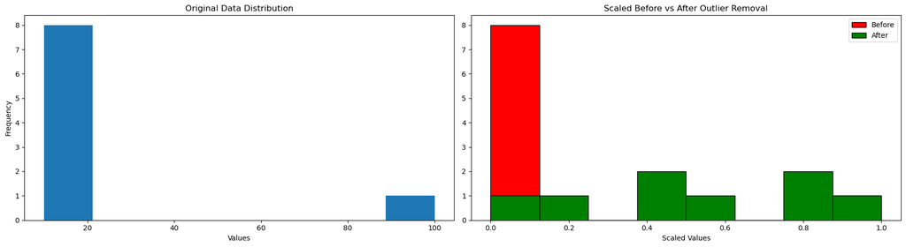

```python
# Simple scaling function (min-max)
def normalize(data):
    clean = [v for v in data if v not in ('', None)]
    if not clean:
        return [None for _ in data]
    min_val = min(clean)
    max_val = max(clean)
    if min_val == max_val:
        return [0 if v not in ('', None) else None for v in data]
    result = []
    for v in data:
        if v in ('', None):
            result.append(None)
        else:
            result.append((v - min_val) / (max_val - min_val))
    return result

# Simple IQR outlier removal
def remove_outliers(data):
    clean = [v for v in data if v not in ('', None)]
    if not clean:
        return data
    sorted_data = sorted(clean)
    n = len(sorted_data)

    q1 = sorted_data[n // 4]
    q3 = sorted_data[(3 * n) // 4]
    iqr = q3 - q1
    lower = q1 - 1.5 * iqr
    upper = q3 + 1.5 * iqr

    # Keep None/'' in same positions
    result = []
    for v in data:
        if v in ('', None):
            result.append(None)
        elif lower <= v <= upper:
            result.append(v)
        else:
            result.append(None)  # remove outlier
    return result

# Example Data
data = [10, 12, 14, 15, 13, 100, 12, 11, 14]  # 100 is outlier

# Scale BEFORE outlier removal
scaled_before = normalize(data)

# Remove outliers
cleaned_data = remove_outliers(data)

# Scale AFTER outlier removal
scaled_after = normalize(cleaned_data)

# Output Results
print("Original Data:       ", data)
print("Scaled BEFORE remove:", scaled_before)
print("Cleaned Data:        ", cleaned_data)
print("Scaled AFTER remove: ", scaled_after)

orig_clean = [v for v in data if v is not None]
scaled_before_clean = [v for v in scaled_before if v is not None]
scaled_after_clean = [v for v in scaled_after if v is not None]

plt.figure(figsize=(18,5))

# Original data
plt.subplot(1,2,1)
plt.hist(orig_clean, bins=8)
plt.title("Original Data Distribution")
plt.xlabel("Values")
plt.ylabel("Frequency")

# Scaled before and after outlier removal
plt.subplot(1,2,2)
plt.hist(scaled_before_clean, bins=8,edgecolor="black",color="red",label="Before")
plt.hist(scaled_after_clean, bins=8,edgecolor="black",color="green",label="After")
plt.title("Scaled Before vs After Outlier Removal")
plt.legend()
plt.xlabel("Scaled Values")


plt.tight_layout()
plt.show()
```

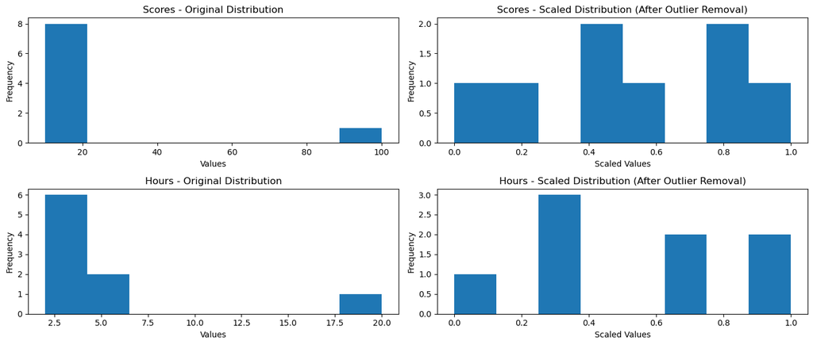

```
Original Dataset:
scores : [10, 12, 14, 15, 13, 100, 12, 11, 14]
hours : [2, 3, 5, 4, 3, 20, 4, 3, 5]

Scaled Dataset (After Outlier Removal):
scores : [0.0, 0.4, 0.8, 1.0, 0.6, None, 0.4, 0.2, 0.8]
hours : [0.0, 0.3333333333333333, 1.0, 0.6666666666666666, 0.3333333333333333, None, 0.6666666666666666, 0.3333333333333333, 1.0]
```

```python
import matplotlib.pyplot as plt

# -----------------------------
# Min-Max Scaling Function
# -----------------------------
def normalize(data):
    clean = [v for v in data if v not in ('', None)]
    if not clean:
        return [None for _ in data]

    min_val = min(clean)
    max_val = max(clean)

    if min_val == max_val:
        return [0 if v not in ('', None) else None for v in data]

    return [(v - min_val) / (max_val - min_val) if v not in ('', None) else None for v in data]


# -----------------------------
# IQR Outlier Removal Function
# -----------------------------
def remove_outliers(data):
    clean = [v for v in data if v not in ('', None)]
    if not clean:
        return data[:]

    sorted_data = sorted(clean)
    n = len(sorted_data)

    q1 = sorted_data[n // 4]
    q3 = sorted_data[(3 * n) // 4]
    iqr = q3 - q1

    lower = q1 - 1.5 * iqr
    upper = q3 + 1.5 * iqr

    return [v if (v not in ('', None) and lower <= v <= upper) else None for v in data]


# -----------------------------
# Original Dataset
# -----------------------------
original_data = {
    "scores": [10, 12, 14, 15, 13, 100, 12, 11, 14],
    "hours":  [2, 3, 5, 4, 3, 20, 4, 3, 5]
}

# -----------------------------
# Scaling After Outlier Removal
# -----------------------------
scaled_dataset = {}

for col, values in original_data.items():
    cleaned = remove_outliers(values)
    scaled_dataset[col] = normalize(cleaned)

# -----------------------------
# Helper Function for Plotting
# -----------------------------
def clean_for_plot(data):
    return [v for v in data if v is not None]


# -----------------------------
# Visualization
# -----------------------------
plt.figure(figsize=(14, 6))
plot_index = 1

for col in original_data:
    # Original data
    original_clean = clean_for_plot(original_data[col])

    # Scaled data
    scaled_clean = clean_for_plot(scaled_dataset[col])

    # Original distribution
    plt.subplot(2, 2, plot_index)
    plt.hist(original_clean, bins=8)
    plt.title(f"{col.capitalize()} - Original Distribution")
    plt.xlabel("Values")
    plt.ylabel("Frequency")

    # Scaled distribution
    plt.subplot(2, 2, plot_index + 1)
    plt.hist(scaled_clean, bins=8)
    plt.title(f"{col.capitalize()} - Scaled Distribution (After Outlier Removal)")
    plt.xlabel("Scaled Values")
    plt.ylabel("Frequency")

    plot_index += 2

plt.tight_layout()
plt.show()


# -----------------------------
# Output
# -----------------------------
print("Original Dataset:")
for col, values in original_data.items():
    print(col, ":", values)

print("\nScaled Dataset (After Outlier Removal):")
for col, values in scaled_dataset.items():
    print(col, ":", values)
```

## 20. Explain why z-score scaling produces negative values.

Z-score scaling produces negative values because it measures how far a data point is from the mean relative to the standard deviation. When a value is smaller than the mean, the difference (x−μ) becomes negative, resulting in a negative z-score. A z-score of zero indicates that the value is exactly at the mean, while positive values represent points above the mean. This scaling method centers the data around zero and expresses each value in terms of standard deviation units rather than raw magnitude. Negative values therefore naturally indicate data points that lie below the average. Such representation helps preserve the relative position and spread of the data, which is useful for many machine learning algorithms.

## 21. Identify scenarios where min-max scaling is preferred over z-score.

**Key Points:**

- Rescales values to a **fixed range**.
- Preserves the **shape of the distribution**.
- Sensitive to outliers since min and max determine the scaling.

**When Min-Max Scaling is Preferred:**

- Features with a **known fixed range** (e.g., image pixels 0–255, exam scores 0–100).
- Models requiring **bounded input**, such as neural networks with sigmoid or tanh activation.
- When you want to **preserve the original distribution shape**.
- When the dataset has **few or no extreme outliers**.

## 22. How does scaling affect variance and standard deviation?

## Effect of Scaling on Variance and Standard Deviation

Scaling changes the spread of data, which directly affects variance and standard deviation.

**1. Min-Max Scaling:**  
Min-max scaling compresses all values into a fixed range, usually [0,1]. This reduces both the variance and standard deviation because the range of the data becomes smaller. Relative differences between values are preserved proportionally, but the absolute variability decreases.

**2. Z-Score Scaling:**  
Z-score scaling standardizes the data by centering it around zero and scaling it based on standard deviation. After scaling, the mean becomes 0 and the standard deviation becomes 1. This preserves the shape of the distribution while normalizing the spread of values to unit scale.

**Summary:**

- **Min-Max Scaling:** Variance and standard deviation are reduced, values are compressed.
- **Z-Score Scaling:** Variance = 1, standard deviation = 1, preserving relative distances.
- Overall, scaling affects the magnitude of variability but not the relative positions of the data points.

## 23. Apply scaling to two features with very different ranges and analyze impact.

```
Original Data:
age : [18, 22, 25, 35, 40, 50, 60]
income : [10000, 20000, 30000, 50000, 70000, 90000, 100000]

Min-Max Normalized Data:
age : [0.0, 0.1, 0.17, 0.4, 0.52, 0.76, 1.0]
income : [0.0, 0.11, 0.22, 0.44, 0.67, 0.89, 1.0]

Z-Score Standardized Data:
age : [-1.24, -0.96, -0.75, -0.05, 0.3, 1.0, 1.7]
income : [-1.32, -1.01, -0.71, -0.09, 0.53, 1.15, 1.46]
```

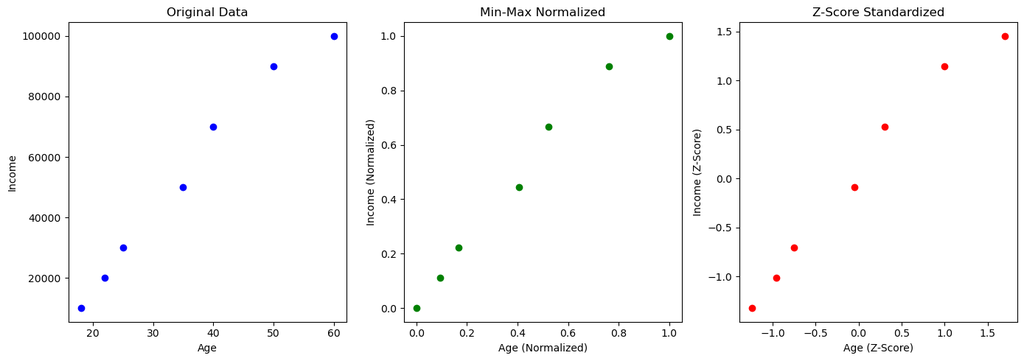

```python
import matplotlib.pyplot as plt

# Your normalization function
def normalization(data):
    if not data:
        return []
    data = [x for x in data if x not in ('', None)]
    min_val = min(data)
    max_val = max(data)

    if min_val == max_val:
        return [0 for _ in data]

    normal = []
    for x in data:
        y = (x - min_val) / (max_val - min_val)
        normal.append(y)
    return normal

# Your standardization function
def standardization(data1):
    data = [x for x in data1 if x not in ('', None)]
    mean = sum(data) / len(data)
    std = (sum((x - mean)**2 for x in data) / len(data)) ** 0.5

    if std == 0:
        return [0 for _ in data]

    standard = []
    for value in data1:
        z = (value - mean) / std
        standard.append(z)

    return standard

# Example dataset with two features of very different ranges
dataset = {
    "age": [18, 22, 25, 35, 40, 50, 60],
    "income": [10000, 20000, 30000, 50000, 70000, 90000, 100000]
}

# Apply Min-Max Scaling
normalized_dataset = {col: normalization(values) for col, values in dataset.items()}

# Apply Z-Score Scaling
standardized_dataset = {col: standardization(values) for col, values in dataset.items()}

# Print results
print("Original Data:")
for col, values in dataset.items():
    print(col, ":", values)

print("\nMin-Max Normalized Data:")
for col, values in normalized_dataset.items():
    print(col, ":", [round(v, 2) for v in values])

print("\nZ-Score Standardized Data:")
for col, values in standardized_dataset.items():
    print(col, ":", [round(v, 2) for v in values])

# Visualization
plt.figure(figsize=(14, 5))

# Original Data Scatter
plt.subplot(1, 3, 1)
plt.scatter(dataset['age'], dataset['income'], color='blue')
plt.title("Original Data")
plt.xlabel("Age")
plt.ylabel("Income")

# Min-Max Normalized Scatter
plt.subplot(1, 3, 2)
plt.scatter(normalized_dataset['age'], normalized_dataset['income'], color='green')
plt.title("Min-Max Normalized")
plt.xlabel("Age (Normalized)")
plt.ylabel("Income (Normalized)")

# Z-Score Standardized Scatter
plt.subplot(1, 3, 3)
plt.scatter(standardized_dataset['age'], standardized_dataset['income'], color='red')
plt.title("Z-Score Standardized")
plt.xlabel("Age (Z-Score)")
plt.ylabel("Income (Z-Score)")

plt.tight_layout()
plt.show()
```

## Analysis of Scaling Impact on Features with Different Ranges

We applied scaling techniques to two features, `age` (18–60) and `income` (10,000–100,000), which have very different ranges.

1. **Original Data:**
   - `Income` dominates the scale compared to `age`, stretching points vertically in the scatter plot.
   - Algorithms sensitive to feature magnitude may overemphasize `income`.
2. **Min-Max Normalization:**
   - Scales both features to the [0, 1] range.
   - Scatter plot shows a balanced distribution along both axes.
   - Relative positions are preserved, and no feature dominates due to range differences.
   - Suitable for models requiring bounded input, such as neural networks.
3. **Z-Score Standardization:**
   - Centers features at mean = 0 and scales to standard deviation = 1.
   - Scatter plot shows negative and positive values, but relative order is maintained.
   - Removes unit differences and standardizes spread, making it ideal for PCA, clustering, or regression.

**Key Takeaways:**

- Scaling balances features with very different ranges.
- Min-Max preserves relative positions while compressing the range.
- Z-Score preserves relative positions while standardizing variance.
- Both techniques help algorithms treat all features equally and improve model performance.

## 24. Explain scaling importance for KNN or K-Means using code examples.

```
KNN Prediction BEFORE scaling: [0]
KNN Prediction AFTER scaling: [0]
```

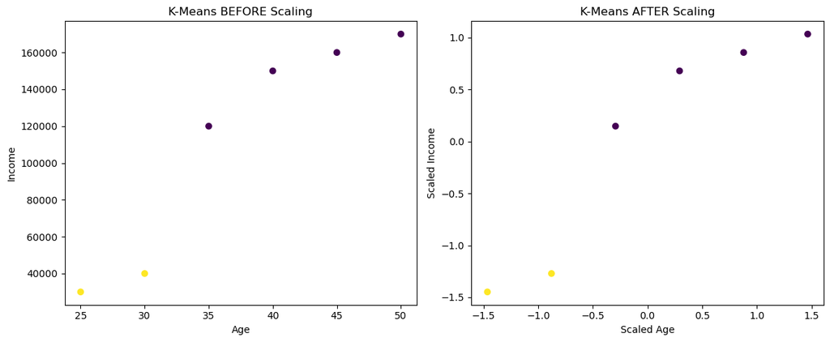

```python
# ----------------------------------------
# IMPORTS
# ----------------------------------------
import matplotlib.pyplot as plt
from sklearn.neighbors import KNeighborsClassifier
from sklearn.cluster import KMeans
from sklearn.preprocessing import MinMaxScaler, StandardScaler

# ----------------------------------------
# DATASET (two features with very different ranges)
# Feature 1: Age (small range)
# Feature 2: Income (large range)
# ----------------------------------------
X = [
    [25, 30000],
    [30, 40000],
    [35, 120000],
    [40, 150000],
    [45, 160000],
    [50, 170000]
]

y = [0, 0, 1, 1, 1, 1]   # target for KNN

# ----------------------------------------
# PART 1: KNN (Before Scaling)
# ----------------------------------------
knn = KNeighborsClassifier(n_neighbors=3)
knn.fit(X, y)

new_point = [[28, 35000]]
pred_before = knn.predict(new_point)

print("KNN Prediction BEFORE scaling:", pred_before)

# ----------------------------------------
# PART 2: KNN (After Scaling)
# ----------------------------------------
scaler_knn = MinMaxScaler()
X_scaled = scaler_knn.fit_transform(X)
new_point_scaled = scaler_knn.transform(new_point)

knn.fit(X_scaled, y)
pred_after = knn.predict(new_point_scaled)

print("KNN Prediction AFTER scaling:", pred_after)

# ----------------------------------------
# PART 3: K-Means (Before Scaling)
# ----------------------------------------
kmeans = KMeans(n_clusters=2, random_state=0)
labels_before = kmeans.fit_predict(X)

# ----------------------------------------
# PART 4: K-Means (After Scaling)
# ----------------------------------------
scaler_kmeans = StandardScaler()
X_scaled_km = scaler_kmeans.fit_transform(X)

kmeans_scaled = KMeans(n_clusters=2, random_state=0)
labels_after = kmeans_scaled.fit_predict(X_scaled_km)

# ----------------------------------------
# VISUALIZATION
# ----------------------------------------
plt.figure(figsize=(12, 5))

# Before Scaling
plt.subplot(1, 2, 1)
plt.scatter(
    [x[0] for x in X],
    [x[1] for x in X],
    c=labels_before
)
plt.xlabel("Age")
plt.ylabel("Income")
plt.title("K-Means BEFORE Scaling")

# After Scaling
plt.subplot(1, 2, 2)
plt.scatter(
    X_scaled_km[:, 0],
    X_scaled_km[:, 1],
    c=labels_after
)
plt.xlabel("Scaled Age")
plt.ylabel("Scaled Income")
plt.title("K-Means AFTER Scaling")

plt.tight_layout()
plt.show()
```

## 25. Design a preprocessing pipeline that includes scaling as one step.

```python
# IMPORT LIBRARIES
from sklearn.pipeline import Pipeline
from sklearn.preprocessing import MinMaxScaler
from sklearn.neighbors import KNeighborsClassifier

# DATA
X = [
    [25, 30000],
    [30, 40000],
    [35, 120000],
    [40, 150000]
]

y = [0, 0, 1, 1]

# PREPROCESSING PIPELINE
pipeline = Pipeline(steps=[
    ("scaling", MinMaxScaler()),          # Step 1: Scaling
    ("model", KNeighborsClassifier(n_neighbors=3))  # Step 2: Model
])

# TRAIN MODEL
pipeline.fit(X, y)

# PREDICTION
new_data = [[28, 35000]]
prediction = pipeline.predict(new_data)
print("Prediction:", prediction)
```

```
Prediction: [0]
```